# Análisis exploratorio: Default de pago de tarjetas de crédito

Relaciones bivariadas agrupadas con interpretación

2026-08-27

## Manipulación de datos

Antes de generar los gráficos, el dataset original de clientes de tarjeta de crédito se sometió a las siguientes transformaciones:

1. **Lectura del archivo Excel**: el dataset se lee con `read_excel()` (paquete `readxl`) desde `credit.xls`, usando `skip = 1` porque la primera fila del archivo original es una fila de encabezado auxiliar (`X1, X2, X3, ...`) y los nombres reales de las columnas están en la segunda fila. El resultado se convierte a `data.frame` estándar y se le aplica `make.names()` para que `default payment next month` (con espacios) se lea de forma consistente como `default.payment.next.month`.
2. **Exclusión de variables de identificación y demográficas**: se excluyeron `ID`, `SEX`, `EDUCATION` y `MARRIAGE` del análisis bivariado. `ID` es solo un identificador, y `SEX`, `EDUCATION` y `MARRIAGE` son categóricas nominales sin orden natural.
3. **Exclusión de las variables `PAY_` (estado de pago) y `default.payment.next.month`**: este análisis se enfoca en `LIMIT_BAL`, `AGE`, `BILL_AMT1-6` y `PAY_AMT1-6`.
4. **Agrupación temática de pares**: los pares se organizaron en 8 grupos temáticos, cada uno con su interpretación correspondiente.
5. **Filtrado de valores no finitos**: para cada par `(x, y)` se eliminaron las filas donde `x` o `y` fueran `NA`, `NaN` o `Inf`, usando `is.finite()`. Cada gráfico puede así usar un subconjunto de filas ligeramente distinto.
6. **No se modificó el dataset original** (`datos`): todas las transformaciones se aplicaron sobre copias locales (`datos_grafico`, `x_grafico`, `y_grafico`) dentro de cada iteración.

Un diccionario de datos completo (significado de cada variable) está disponible en el EDA Analisis Exploratoro de Datos Estadistica Multidimensional.Rmd

## Definición de variables, grupos y unidades

## GRUPO 1: LIMIT_BAL vs. AGE

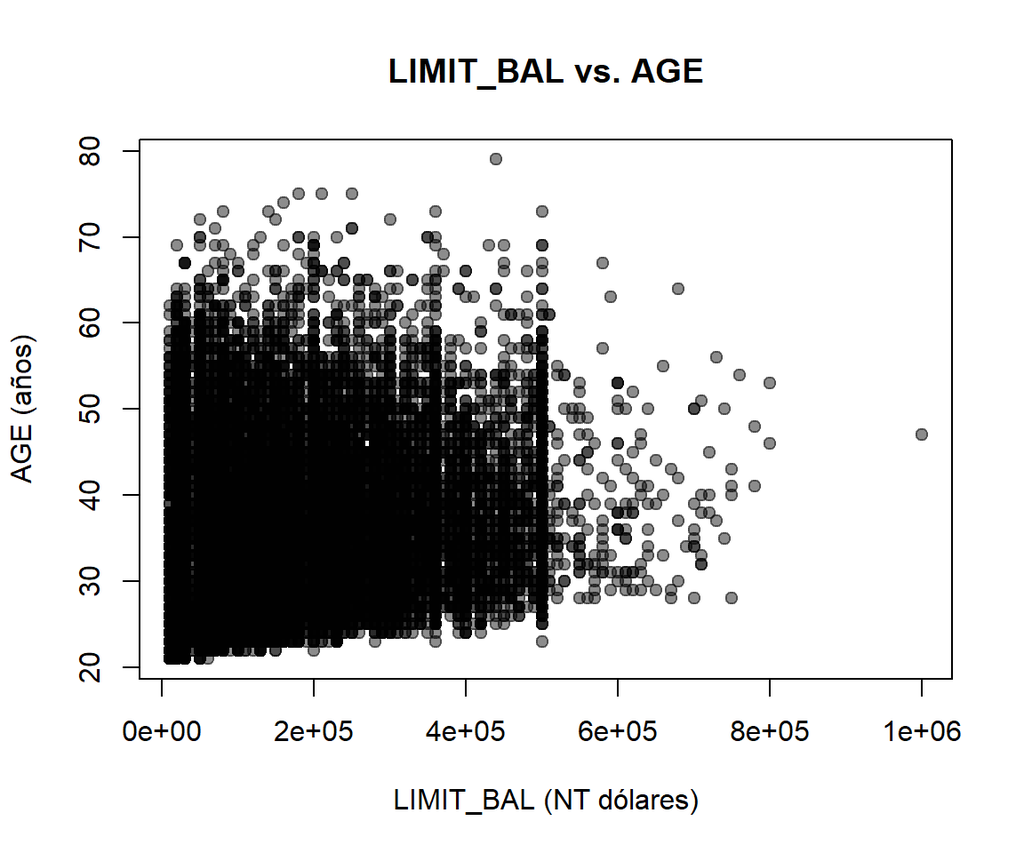

**Interpretación:**

El gráfico representa la relación entre el **límite de crédito otorgado (`LIMIT_BAL`)** y la **edad de los clientes (`AGE`)**.

Se observa una ligera tendencia creciente del límite de crédito entre los 20 y 30 años. Entre aproximadamente los 30 y 40 años se presenta una mayor concentración de los valores, mientras que a partir de edades superiores se observa una menor presencia de límites de crédito elevados.

La mayoría de las observaciones se encuentra por debajo de **NT$500.000**, mientras que los valores superiores a este monto presentan una menor frecuencia.

En términos generales, los valores de límite de crédito más elevados se concentran principalmente en los grupos de edad intermedios, aunque existe una amplia dispersión dentro de cada rango de edad.

## GRUPO 2: LIMIT_BAL vs. BILL_AMT

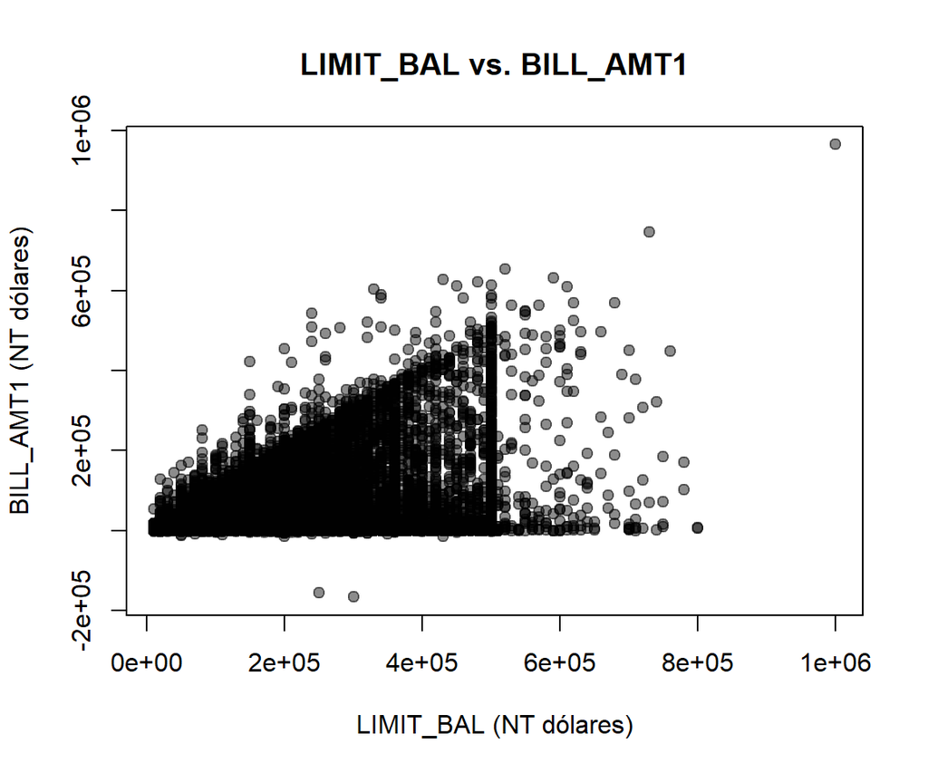

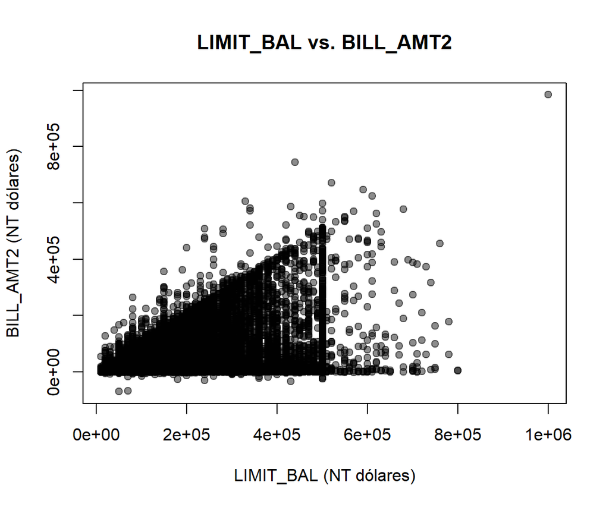

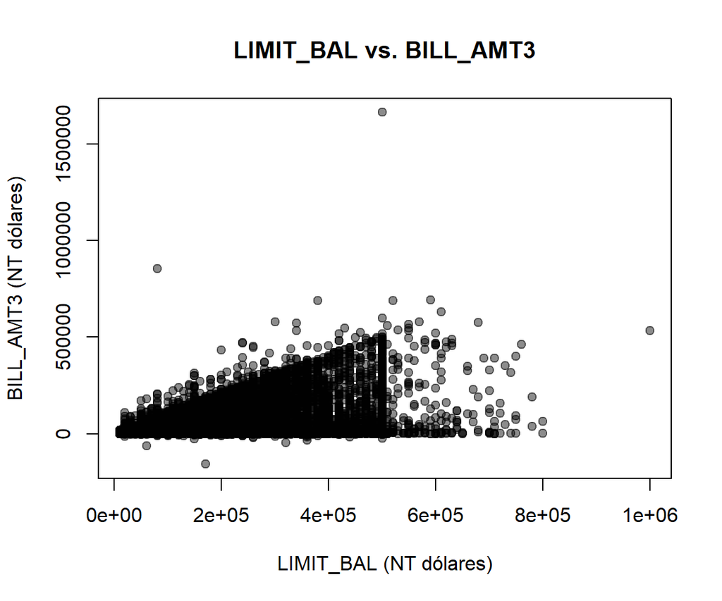

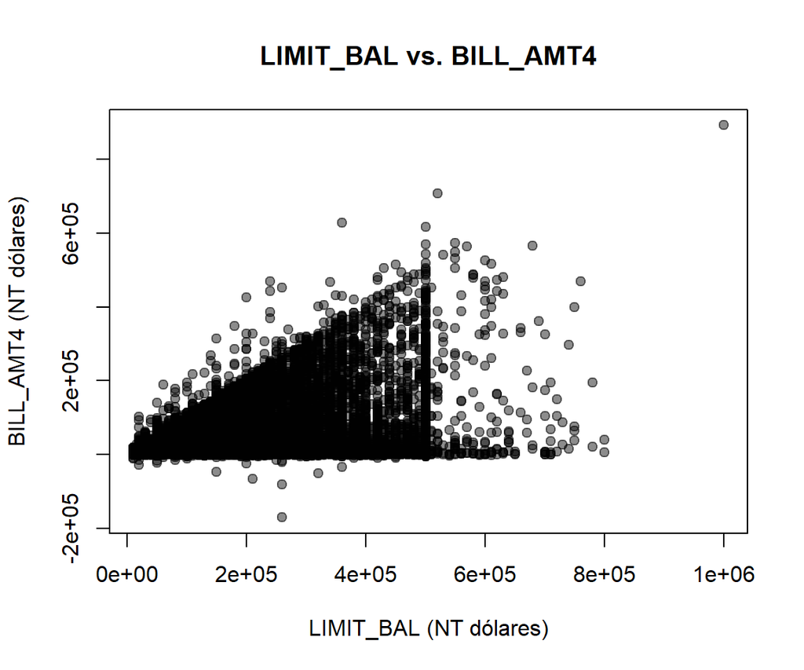

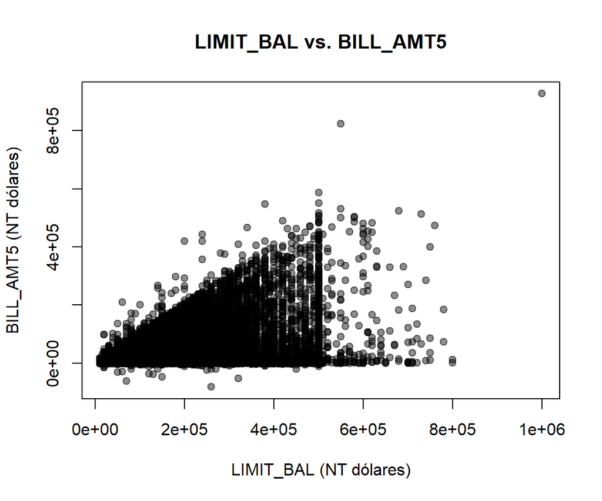

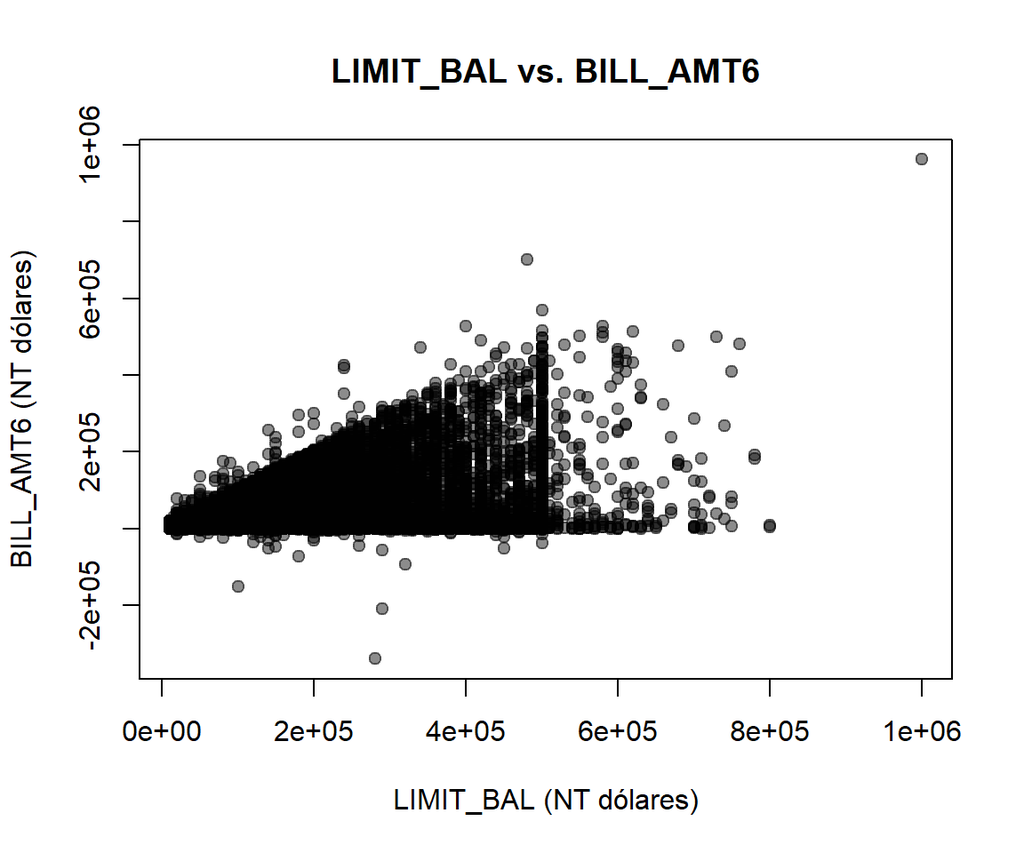

**Interpretación:**

### Montos de los estados de cuenta de septiembre a abril

Este conjunto de gráficos representa la relación entre el **límite de crédito (`LIMIT_BAL`)** y los **montos de los estados de cuenta (`BILL_AMT`)** correspondientes a los diferentes meses.

Los gráficos presentan un comportamiento generalmente **creciente**, observándose que los valores de `BILL_AMT` tienden a incrementarse a medida que aumenta `LIMIT_BAL`.

La mayoría de los puntos se encuentra por debajo de la diagonal correspondiente a una relación **1:1**, lo que indica que los montos registrados en los estados de cuenta son, en la mayoría de las observaciones, inferiores al límite de crédito.

También se observa una franja horizontal alrededor de **`BILL_AMT = 0`**, presente transversalmente para diferentes valores de `LIMIT_BAL`. Esto evidencia la existencia de observaciones con estados de cuenta de valor cero independientemente del límite de crédito.

Por otra parte, alrededor de **NT$500.000** disminuye la concentración de observaciones, debido a la menor presencia de clientes con límites superiores a este valor. Sin embargo, las observaciones existentes por encima de dicho umbral mantienen el comportamiento general observado en el resto de los datos.

## GRUPO 3: LIMIT_BAL vs. PAY_AMT

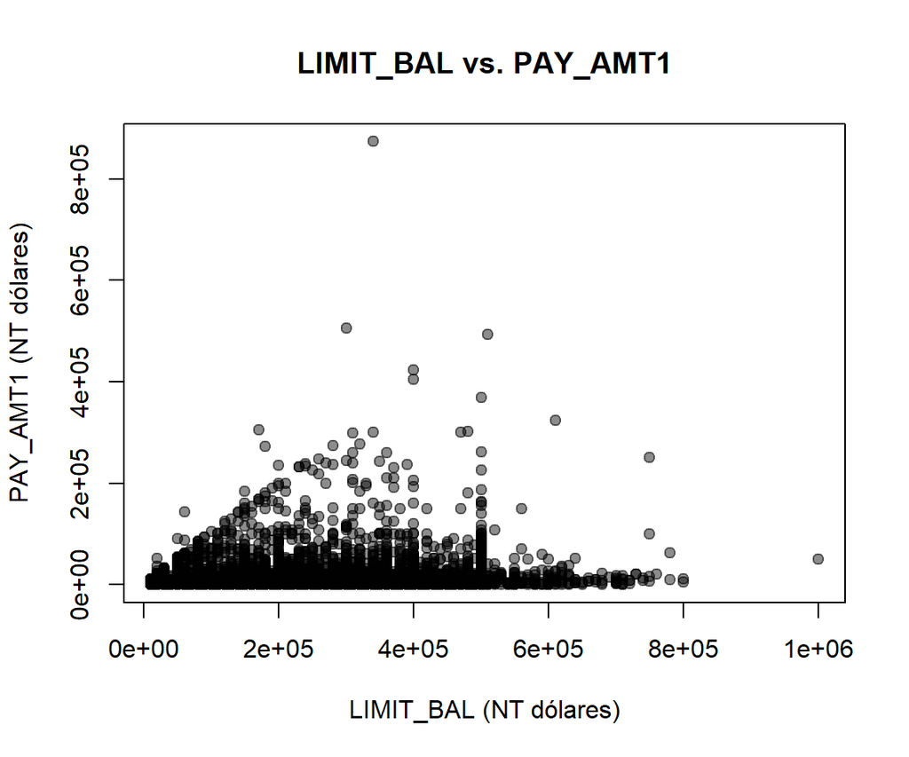

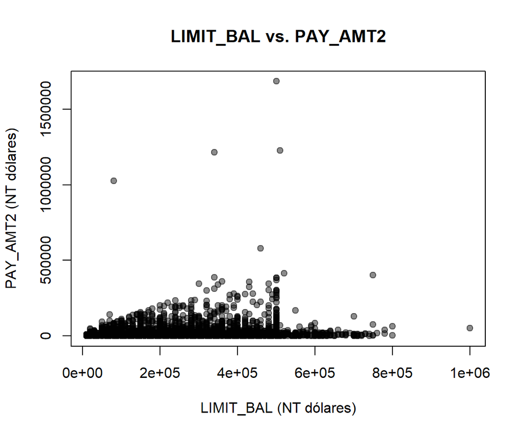

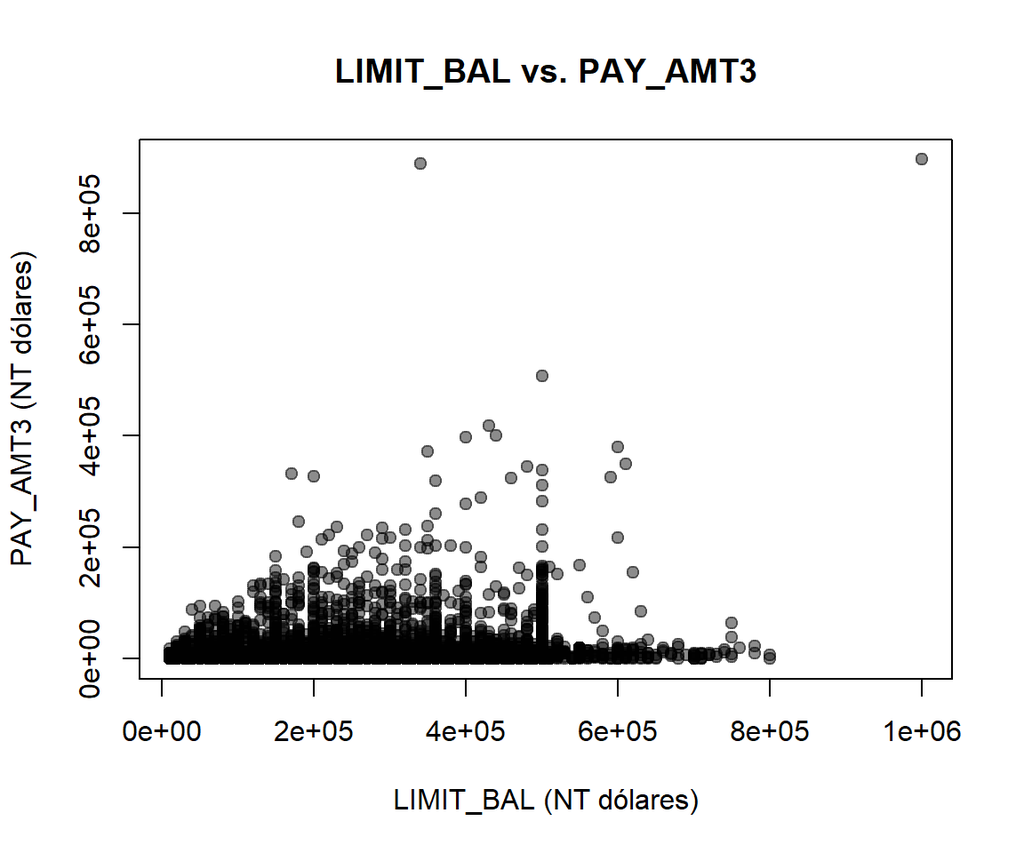

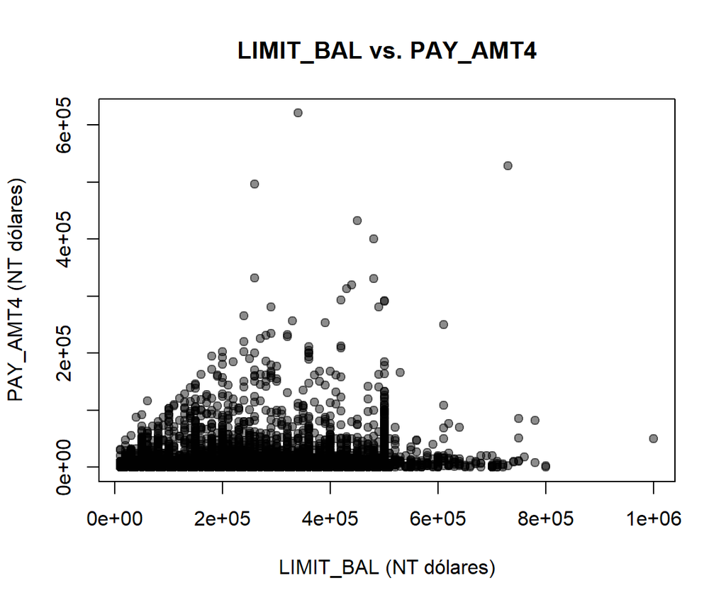

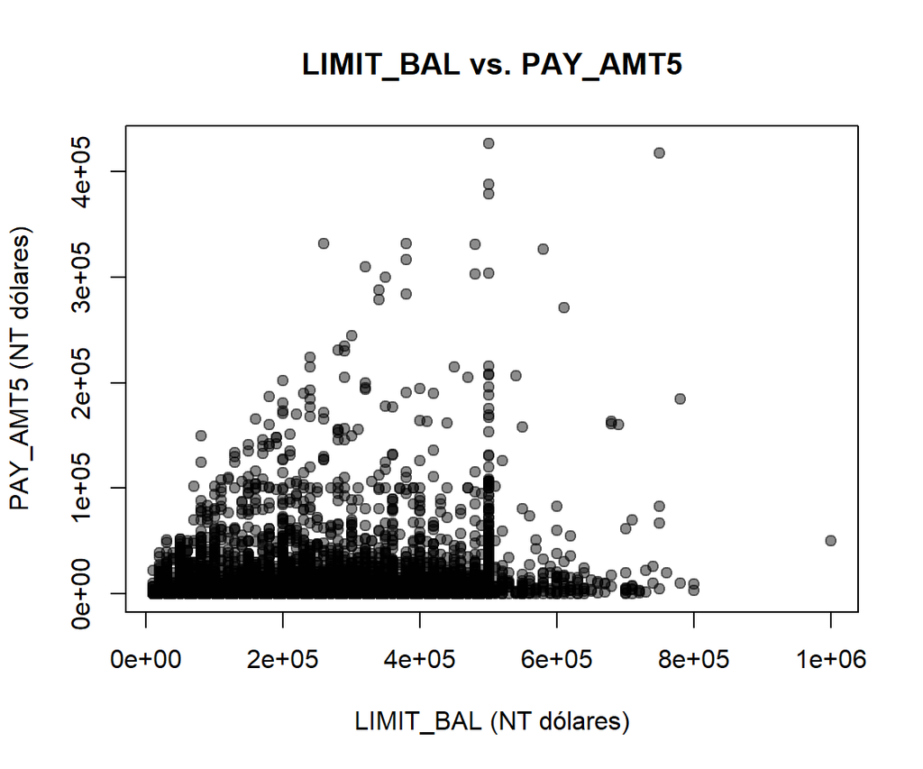

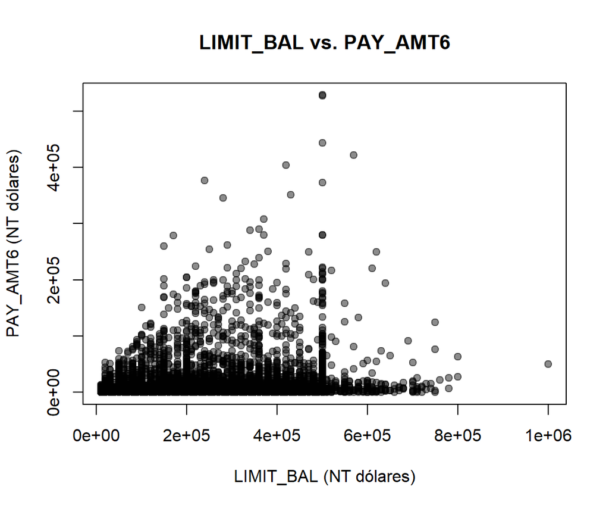

**Interpretación:**

### Pagos realizados de septiembre a abril

Este conjunto de gráficos representa la relación entre el **límite de crédito (`LIMIT_BAL`)** y los **montos de los pagos realizados (`PAY_AMT`)** durante los diferentes meses.

Se observa una alta dispersión de los valores de `PAY_AMT` para los diferentes niveles de `LIMIT_BAL`. Aunque los límites de crédito más elevados presentan algunos pagos de mayor magnitud, no se observa una relación creciente tan marcada como la identificada entre `LIMIT_BAL` y `BILL_AMT`.

Una proporción considerable de las observaciones se concentra en valores bajos de `PAY_AMT`, incluyendo una importante cantidad de valores cercanos a cero.

Al comparar estos gráficos con los correspondientes a `LIMIT_BAL` vs. `BILL_AMT`, se observa que los montos de pago presentan una distribución más concentrada en valores bajos, mientras que los montos de los estados de cuenta presentan una mayor dispersión.

En general, los pagos presentan una relación menos pronunciada con el límite de crédito que los montos registrados en los estados de cuenta.

## GRUPO 4: AGE vs. PAY_AMT y BILL_AMT

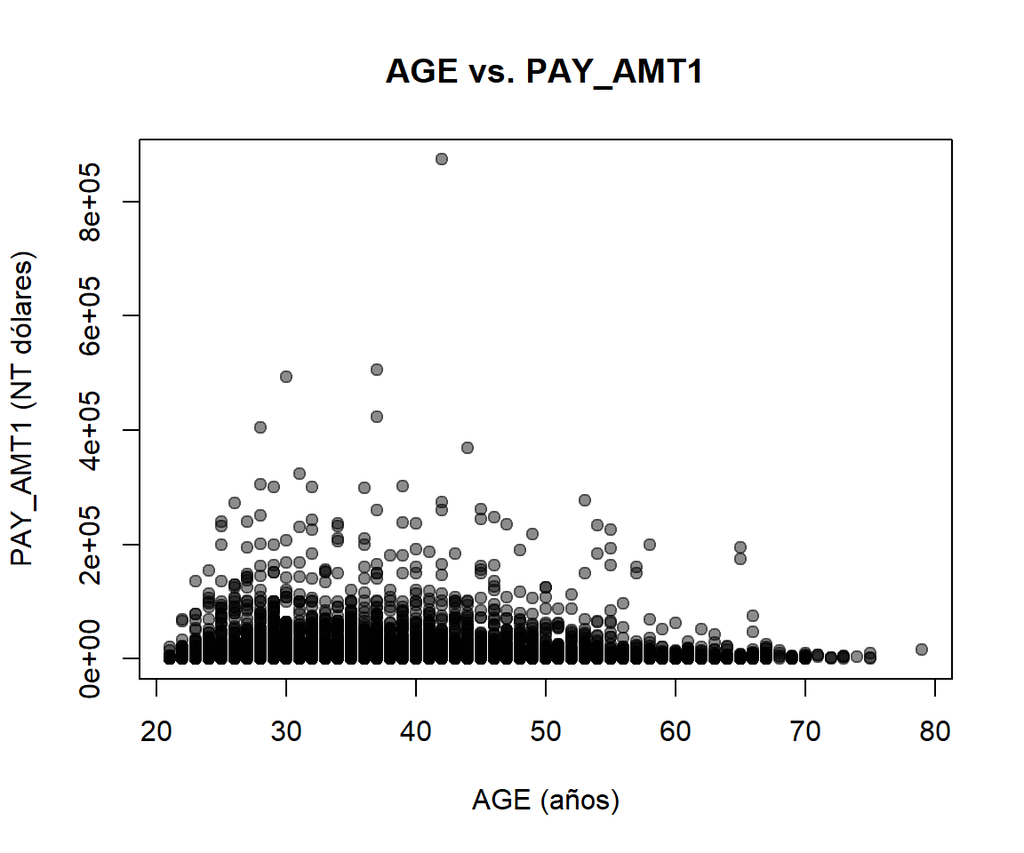

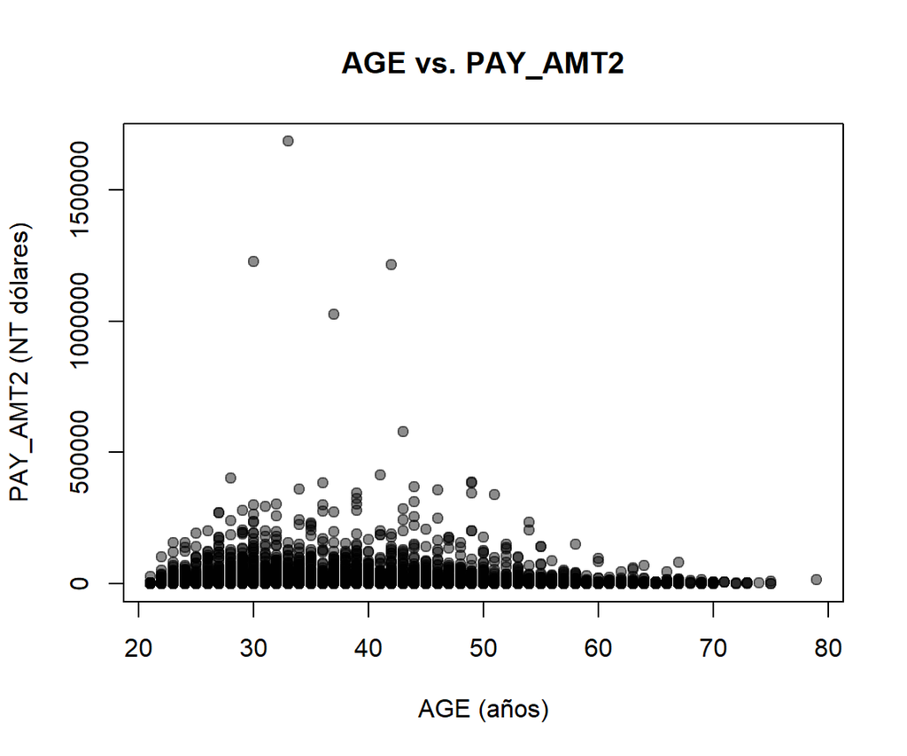

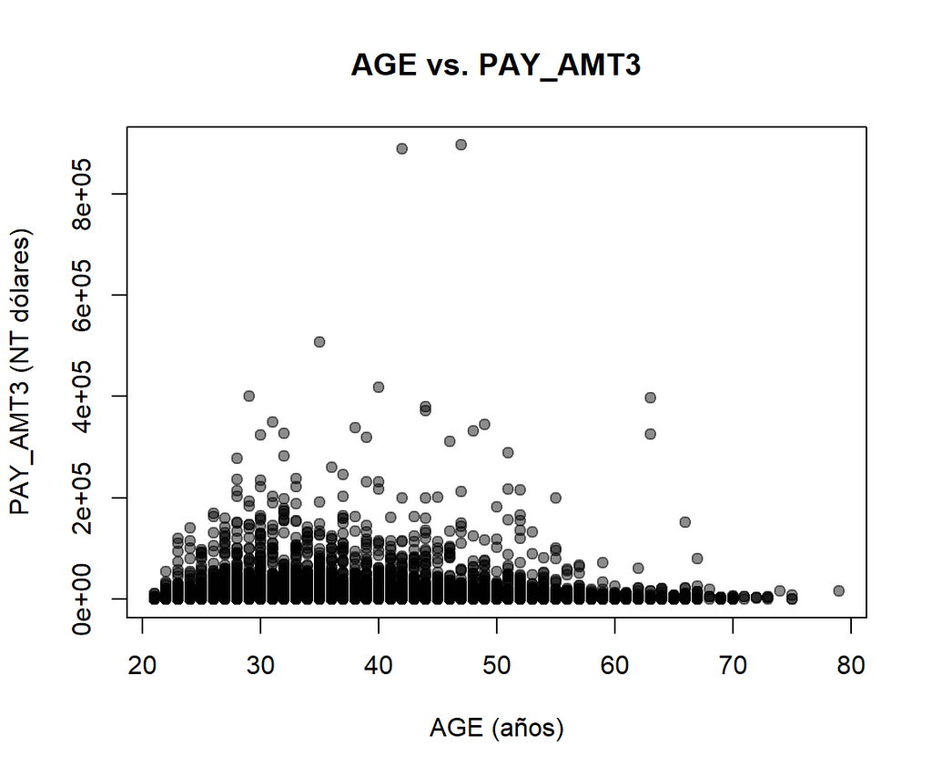

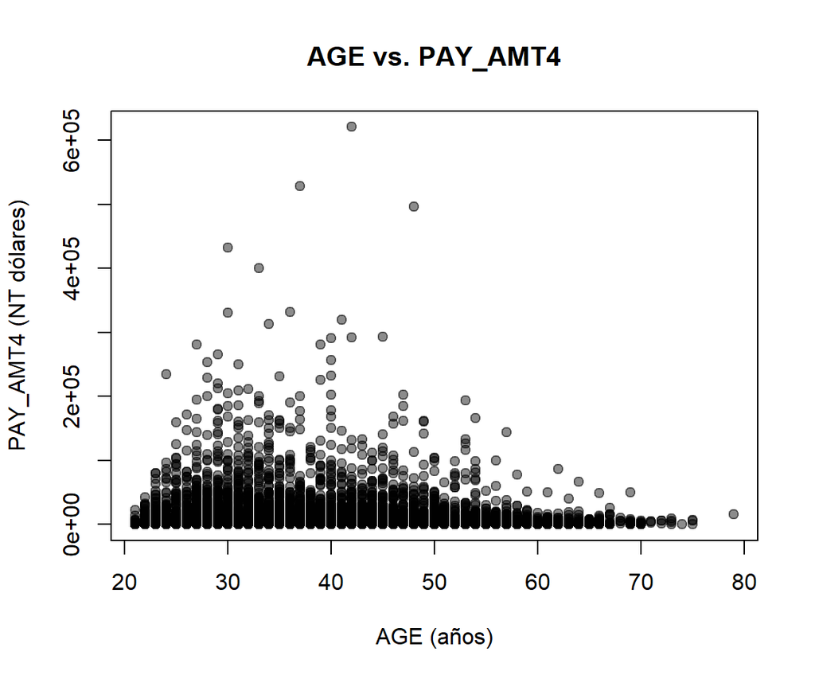

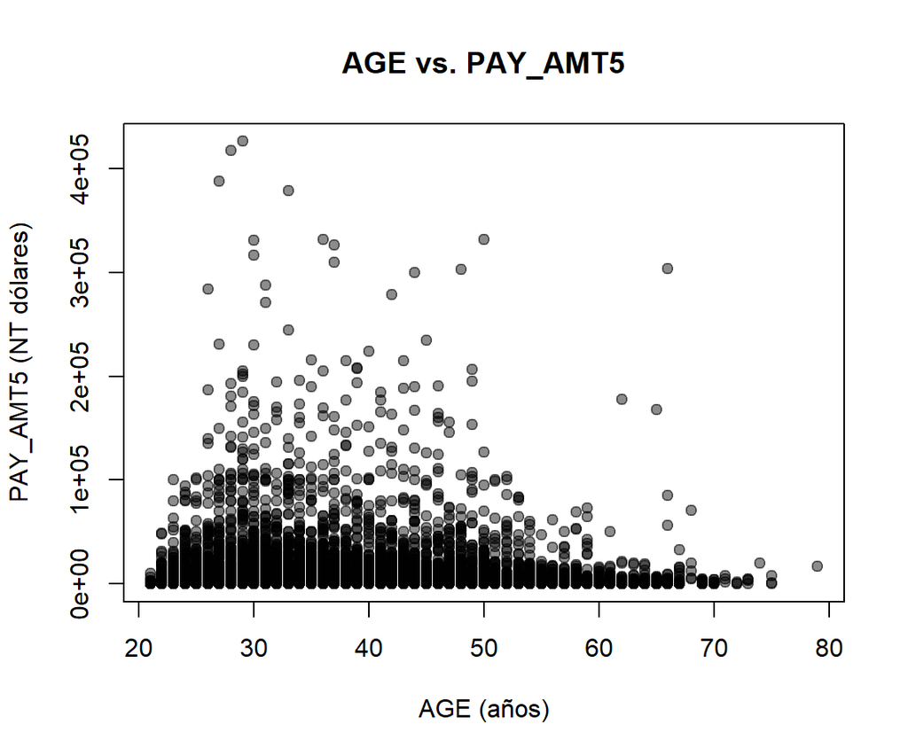

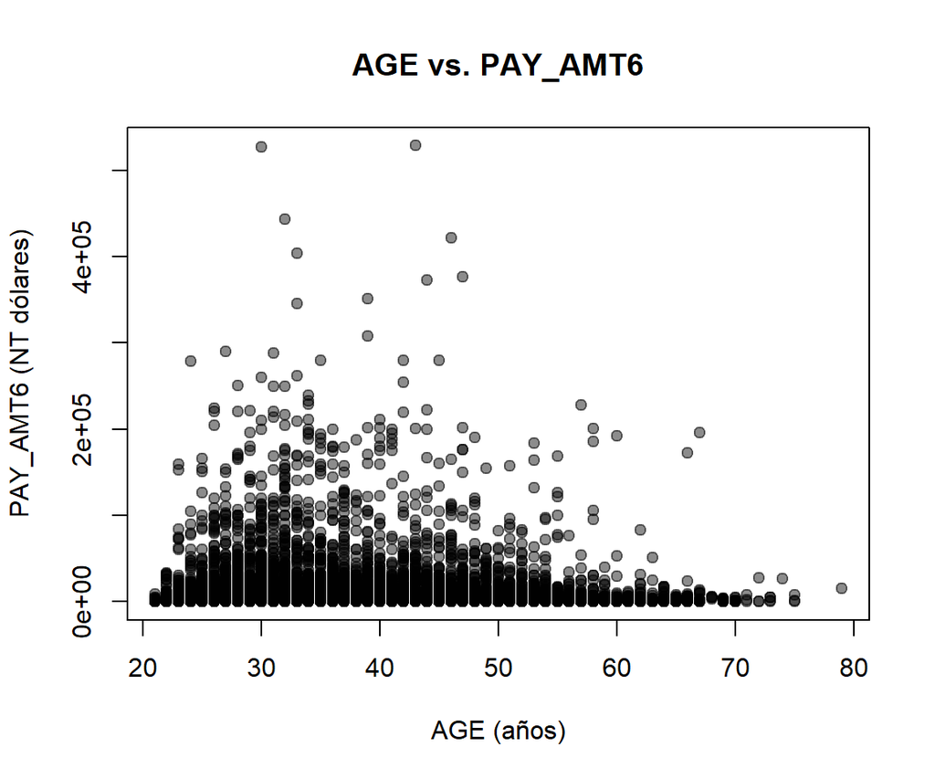

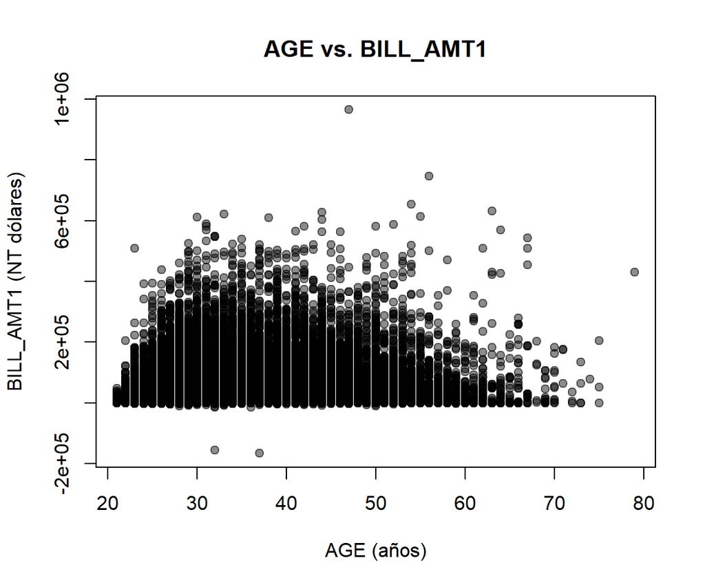

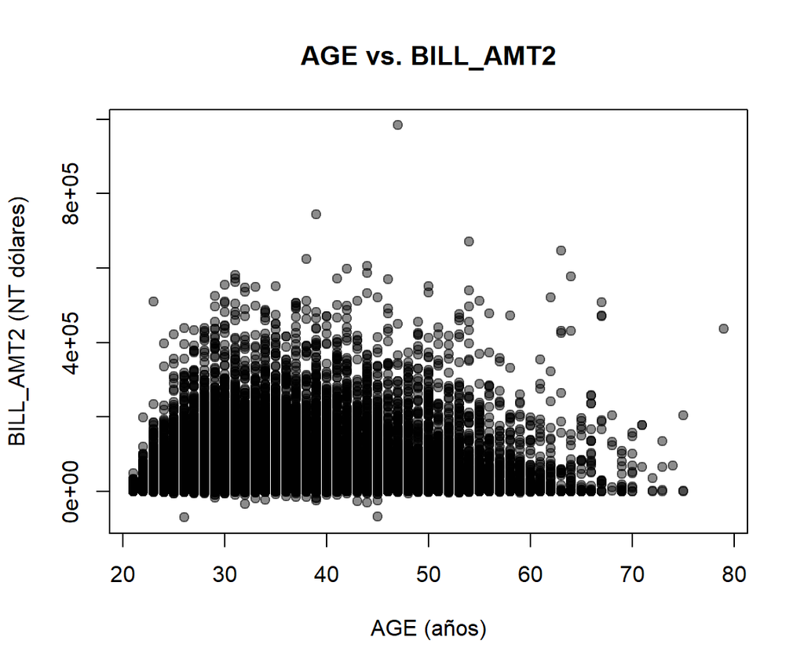

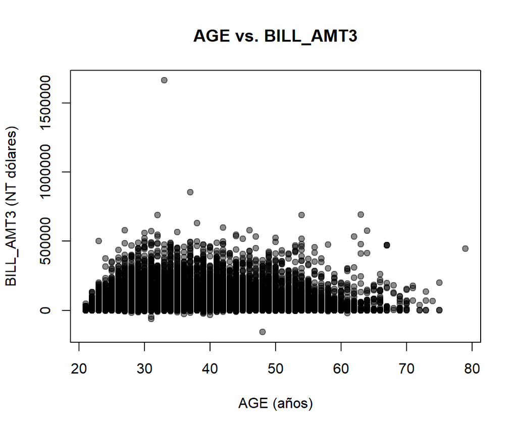

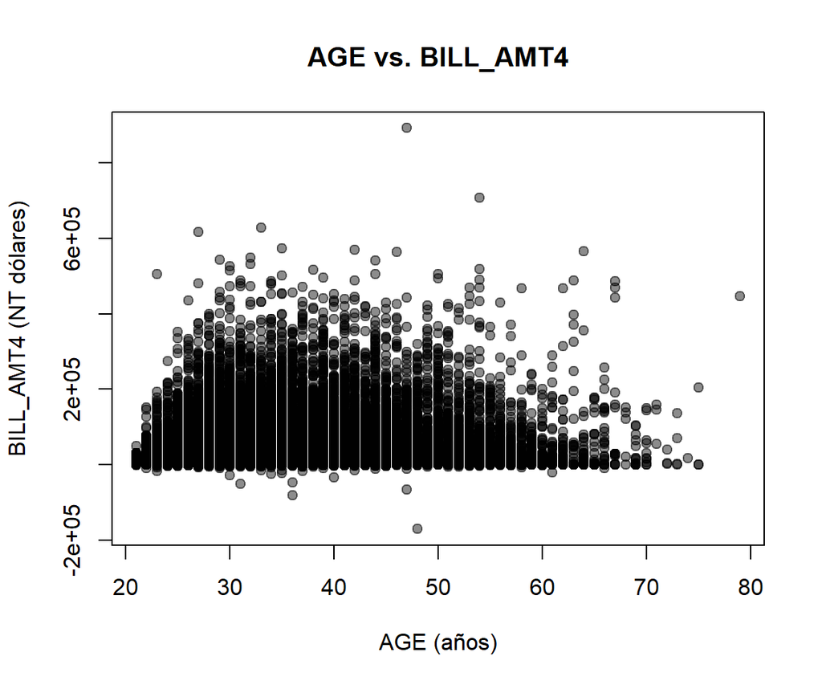

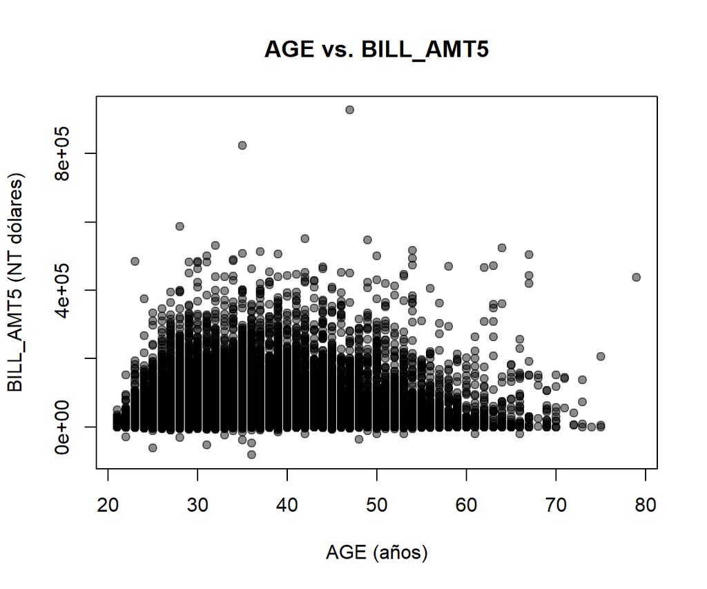

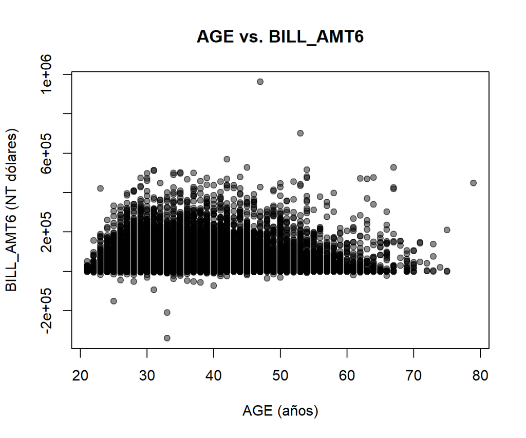

**Interpretación:**

Este grupo representa la relación entre la **edad de los clientes (`AGE`)** y los **montos de pago (`PAY_AMT`)**, así como entre la edad y los **montos de los estados de cuenta (`BILL_AMT`)**.

En los gráficos de `AGE` vs. `PAY_AMT` se observa una alta concentración de los valores de pago en rangos bajos, con una cantidad relativamente reducida de observaciones en valores elevados.

En los gráficos de `AGE` vs. `BILL_AMT` se presenta una mayor dispersión vertical y una presencia más significativa de valores elevados. La mayor concentración de estos valores se encuentra aproximadamente entre los 20 y 50 años, con una presencia notable de montos elevados alrededor de los 30 y 40 años.

También se aprecia una diferencia importante entre las escalas de ambas variables. Los valores de `PAY_AMT` presentan una concentración mucho mayor alrededor de los valores bajos, mientras que `BILL_AMT` presenta una dispersión más amplia y valores máximos considerablemente superiores.

En general, los gráficos muestran una mayor variabilidad en los montos de los estados de cuenta que en los montos de los pagos realizados.

## GRUPO 5: BILL_AMT1 y BILL_AMT2 vs. BILL_AMT

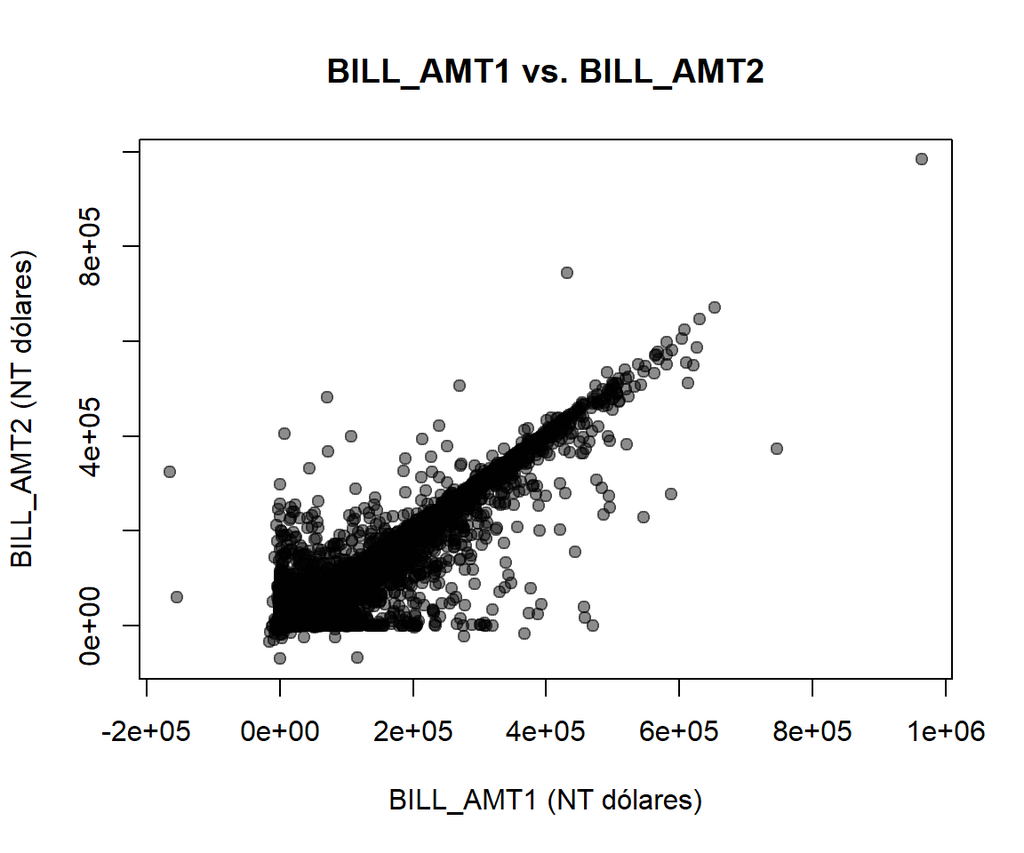

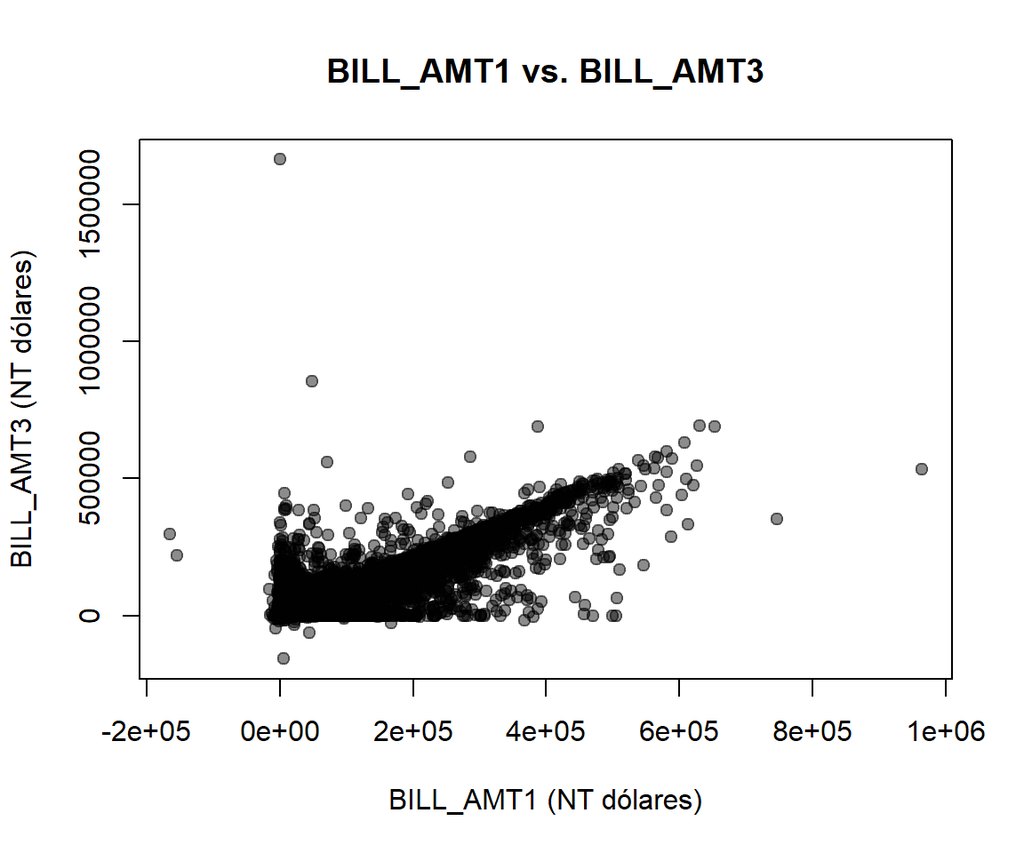

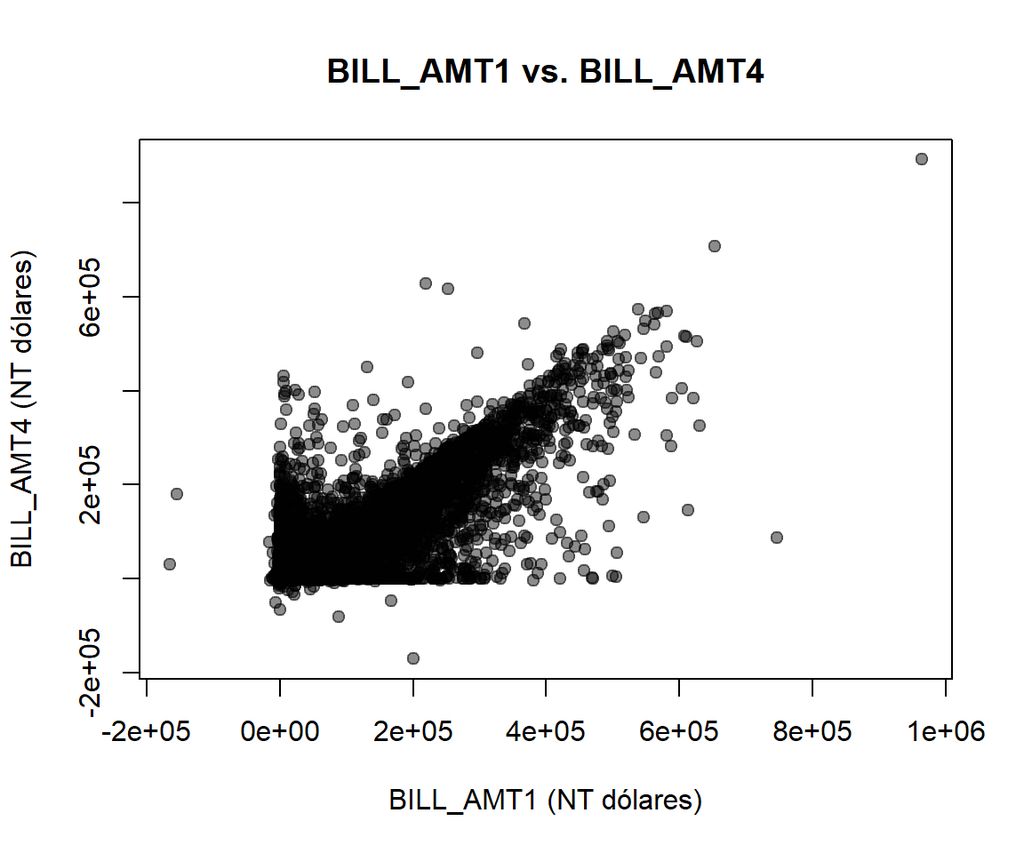

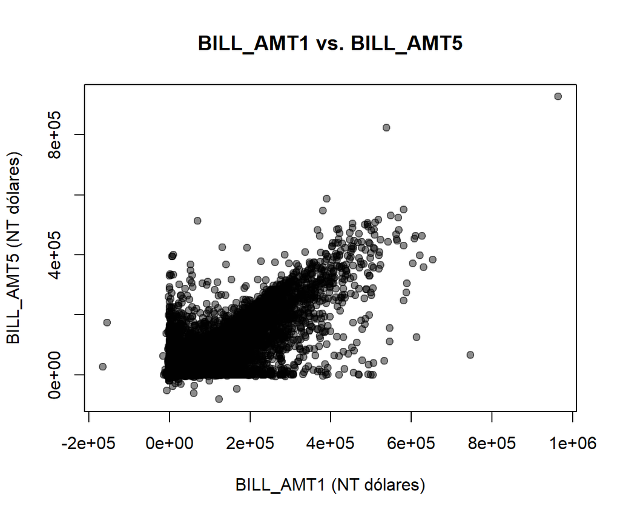

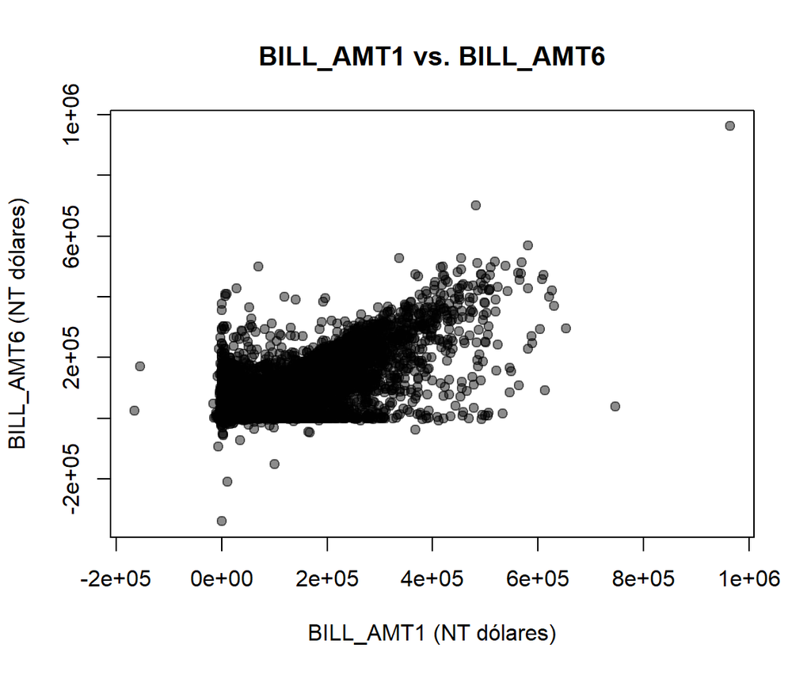